# BAIS6100_Group Project

#### Checking for highest accuracy and testing on test data

```python
text1 = "The Red Magic 7 Pro uses a slower 120Hz 6.8-inch AMOLED display but boasts the same features as the non-Pro version. It has the HDR10 and HLG certification and offers a 720Hz touch sampling rate with several fingers.Yet again, nubia fails to introduce a boost in display brightness when the display operates in Auto mode. In manual mode, the panel can do 447 nits, which is not nearly enough for comfortable outdoor use, and it's far from the advertised 600 nits. Today's flagships comfortably push through the 1,000 nits ceiling, and even the standard Red Magic 7 can output almost 100 nits more.Color accuracy, on the other hand, is the best we've measured on a Red Magic phone. At least if you use it in sRGB mode. You can hardly notice the blue-ish tinge on the bright white, while grays are pretty accurate. The average dE2000 is just 1.5, while the maximum is 3.9. Those are some impressive metrics, but this mode limits the brightness even further at just 410 nits. So if you are okay with the blue-ish whites and grays, use it with the default color preset.The only smart adjustment the system applies to the refresh rate is when you are watching full-screen videos. Only then the system limits the refresh rate to 60Hz instead of going all the way up to 120Hz. The maximum refresh rate is ensured across all system menus and most of the apps. We've played around with one of the most commonly used and found that Chrome and Instagram, for example, are locked at 60Hz, even when 120Hz is enabled. The default Gallery app is also locked at 90Hz, even when watching full-screen videos.One would expect that the Red Magic 7 Pro, which holds a 5,000 mAh battery, has a little longer battery life than the 4,500 mAh-powered vanilla version. That's not what our tests show, however. There seems to be an issue with the standby and web browsing runtimes. They are both considerably lower than the ones we got with the Red Magic 7. Our battery tests were automated thanks to SmartViser, using its viSerDevice app. The endurance rating denotes how long the battery charge will last you if you use the device for an hour of telephony, web browsing, and video playback daily. More details can be found here.  Video test carried out in 60Hz refresh rate mode. Web browsing test done at the display's highest refresh rate whenever possible. Refer to the respective reviews for specifics. To adjust the endurance rating formula to match your own usage patterns check out our all-time battery test results chart where you can also find all phones we've tested. There's no apparent reason for these results as both handsets share the same hardware and software. Sure, there's a difference in the display panels (one is 165Hz, and the other one is 120Hz), but the inconsistencies are across all tests, including the 3G talk time. The two devices scored the same 25h talk time too.This leads us to believe that there's a software issue that, once fixed, should have the standby battery drain sorted out and potentially improve the screen-on tests as well. At least the video playback test returned a solid 15h score.The Red Magic 7 Pro charges faster than its more affordable sibling, even though it carries a bigger battery. The 5,000 mAh unit was able to charge from 0 to 100% in just 28 minutes using the same 65W Power Delivery 3.0 charger the other phone uses. The vanilla version of the device has a 4,500 mAh battery and charges 10 minutes slower.Higher is betterLower is betterAs before, running the cooling fan during charging didn't change the final result; it only barely reduced the surface temperatures.The non-Pro model features a standard stereo loudspeaker setup with the earpiece doubling as a secondary loudspeaker, whereas the Pro version has two dedicated speakers placed on the bottom and top of the side frame. The main advantage of such a setup is balance, but we can't say that this implementation is well-balanced. In fact, the left (top) speaker sounds borderline muffled while the right one (bottom) contributes to the overall loudness the most. Speaking of which, the -22.6 LUFS score is enough for an score in loudness, and it's also good enough to put it among the loudest devices on the market.Sadly, in addition to imbalanced sound, the highs and mids start to at higher volumes. Distortion is apparent, so for optimal sound quality, we suggest keeping the volume a few clicks away from the maximum. Bass and overall fullness are great, though, throughout all volume levels.Use the Playback controls to listen to the phone sample recordings (best use headphones). We measure the average loudness of the speakers in LUFS. A lower absolute value means a louder sound. A look at the frequency response chart will tell you how far off the ideal flat line is the reproduction of the bass, treble, and mid frequencies. You can add more phones to compare how they differ. The scores and ratings are not comparable with our older loudspeaker test. Learn more about how we test here."
text2 = "The Redmi Note 11S uses the same screen we experience on the Redmi Note 11, an upgraded version of the Redmi Note 10S panel. It is a 6.43-inch AMOLED of 1080p resolution and 90Hz refresh rate.The exact resolution of the OLED panel is 1,080 x 2,400 px or 409ppi. A flat sheet of Gorilla Glass 3 handles the screen protection.The AMOLED screen of the Redmi Note 11S supports DCI-P3 color space. The official numbers for the screen brightness are 700nits for the sunlight mode and 1000nits for local peak. There is no HDR support whatsoever.The max brightness we measured on our matches what Xiaomi promises. The numbers are also identical to what we've captured on the vanilla Redmi Note 11.The Redmi Note 11S has a typical maximum brightness of 465 nits, but it can reach 744nits when the automatic sunlight/bright light boost kicks in.Meanwhile, the minimum brightness is just 2.1 nits, similar to what we've seen on the other Redmi Note 11 phones and an excellent one.Color accuracyThe display on the Redmi Note 11S supports DCI-P3 wide color space, just like the rest of the Note 11 models. The screen settings offer three different color models - Vivid (default, DCI-P3), Saturated (DCI-P3 with boosted saturation), and Standard (sRGB accurate). You can tweak the color temperature for each mode.The default Vivid option is tuned to reproduce DCI-P3 rather well, and we did find it to be fairly accurate, excluding the slightly bluish-white and gray colors. Then there is the Standard mode, which has a perfect accuracy to sRGB, including the white and gray hues.Refresh rateThe Redmi Note 11S display supports 60Hz (Standard) and 90Hz (High) refresh rates. The default 90Hz option uses 90Hz most of the time, though it switches between 90Hz and 60Hz on static pictures and interface. Other than that, the screen also reverts to 60Hz for video playback and across apps that cannot support higher than 60Hz.The Redmi Note 11S has a rather weak GPU, and even if high refresh gaming is theoretically possible, we doubt you will be able to run games at higher than 60fps even on lower graphics settings.StreamingThe Redmi Note 11S has Widevine L1 DRM support out of the box, and it can stream Full HD content from all popular video services. There is no HDR support on the phone, and HDR video streaming is not possible.All Redmi Note 11 smartphones are powered by 5,000mAh batteries, and the Note 11S is no different. The Redmi Note 11S has the same battery and chipset as the Redmi Note 11 Pro, though its AMOLED screen is smaller in size, and we can expect more Screen-On-Time on some of the battery tests.So, the Redmi Note 11S scored an outstanding endurance rating of 133 hours. It indeed posted much better times on the screen tests, both web and video, while the call time is a match to the Note 11 Pro.Another thing that's drastically better than the otherwise identical Note 11 Pro is the standby performance - the power consumption is much lower on the Note 11S. All test results shown are achieved under the highest screen refresh rate mode. You can adjust the endurance rating formula manually so it matches better your own usage in our all-time battery test results chart where you can also find all phones we've tested. The Xiaomi Redmi Note 11S comes with a large 5,000mAh battery, and it supports 33W Xiaomi fast charging. The phone ships with the needed power adapter, so you can fast charge it straight away.We tested the Redmi Note 11S with the bundled 33W charger, and the experience is indeed satisfying. The original power adapter takes the battery from 0% to 59% in 30 minutes. This is even faster than the same battery and charger on the vanilla Redmi Note 11, and the only variable that could account for this noticeable difference is the chipset.Higher is betterA full charge requires 62 minutes - that's plenty fast! This time is also better than the Redmi Note 11's 78 minutes, and once again, we can only guess it's a Qualcomm vs. MediaTek difference.Lower is betterThe Redmi Note 11S has two symmetrically placed speakers. They are found behind grills on the top and bottom sides. The speaker above the screen has two outlets - one front-facing and one top-firing, and unlike on other Redmi Note 11 phones, it is incredibly weak on the Note 11S. We'd say it acts like a slightly amplified earpiece instead of an actual speaker.Meanwhile, the bottom speaker is powerful, and we can hear both bass and mid-tones. The earpiece is responsible for high frequencies mostly. Luckily, those are tuned quite right, the sound is balanced, and the multimedia experience is pleasant.The Redmi Note 11S scored a Very Good mark on our loudness test, just like the other Note 11 models.The sound quality is good, even if our tool didn't manage to capture it well. In real life, we could hear good mid-tones and minor bass, in addition to the well-presented high notes.Use the Playback controls to listen to the phone sample recordings (best use headphones). We measure the average loudness of the speakers in LUFS. A lower absolute value means a louder sound. A look at the frequency response chart will tell you how far off the ideal flat line is the reproduction of the bass, treble, and mid frequencies. You can add more phones to compare how they differ. The scores and ratings are not comparable with our older loudspeaker test. Learn more about how we test here."
text3 = "The Find X5 Pro's display is a 6.7-inch OLED with high resolution, high refresh rate, high brightness, high color fidelity, high everything - as is the norm in the high-end segment. Using a Samsung-made LTPO2 AMOLED panel, the Find overs variable refresh rate in the 1-120Hz range. The native resolution is 1440x3216 in a 20:9 aspect ratio for a pixel density of 525ppi.Being a 10-bit panel, it also boasts a capability to display up to 1 billion 'colors' for smoother tonal gradations. HDR10+ is supported where the phone could potentially reach 1300nits of brightness, while in ordinary situations, the max brightness is 800nits as per the press materials.When measuring the Find X5 Pro's max brightness at 75% APL (the fill area of the white pixels on the screen), we got 475nits when operating the slider manually and 762nits when the Auto brightness was left in charge in a bright environment. These are essentially the same numbers as the ones we measured on last year's model, as well as this year's OnePlus 10 Pro, which has basically the same panel.Having said that, we've been getting 1000nits on rival models while Galaxies and iPhones can go in excess of 1200nits. How much of a practical advantage that is, is debatable, but the point is that Find X5 Pro isn't among the brightest out there.It may not be the brightest display, but it can be among the most accurate ones. We measured an average dE2000 of 1.2 for the set of sRGB test swatches in Natural mode, which dropped to 0.8 after a gentle nudge of the temperature slider in the warm direction. Natural isn't the default mode, though - Vivid is, and we got less accurate color rendition with the all-too-common blue shift. That too improved with a temperature adjustment, though - pushing the slider all the way to the right got us an average dE2000 of 2.0 for the DCI-P3 swatches.There's also a Pro mode with two sub-modes. Cinematic targets accurate Display P3 reproduction and manages to deliver spectacularly, while Brilliant is just an all-out super-saturated mode.When it comes to HDR, we got Netflix and YouTube to serve HDR streams, but not so much Amazon Prime Video. Both Netflix and Prime happily played back in 1080p - naturally, the phone has the Widevine L1 certification needed for that.Refresh rate is handled by a simple menu with just two options - Standard and High. Standard sets the RR ceiling at 60Hz, while High allows it to go all the way up to the maximum 120Hz. Both modes employ auto switch-down to whatever RR the software logic decides is most appropriate at the moment based on app, content, and activity.The minimum screen refresh rate is dependent on the screen brightness level. We observed the phone drop to the promised 1Hz when idling but only when set to nearly its maximum brightness level. Just below that, there's another narrow brightness range where the minimum RR is 5Hz, and below that, for the widest brightness range, the minimum RR when idling is 10Hz. At very low brightness levels, we had constant 120Hz readings.In general, the Find will seize every opportunity to drop to a minimum refresh rate (the brightness mandated one) when you don't touch it for even a brief instant. That's the behavior across the UI, in social apps, in browsers, and even in video apps (like YouTube or Netflix) as long as there's no video actually playing.Speaking of, videos were treated somewhat weirdly in our experience, with 24fps clips getting a 30Hz refresh rate and the phone reporting a constantly changing 30Hz-60Hz refresh rate for 48fps videos (maybe a peculiarity in reporting, and it was, in fact, a steady 48Hz?). 30fps and 60fps videos do get as many Hz as fps.Browsers tend to remain at 60Hz when there's moving content being displayed, but they will both drop to the minimum for static pages when idling and also spike to 120Hz when you touch the screen to scroll. Games appear limited to 60Hz, though.The Find X5 Pro is equipped with a 5,000mAh battery - a meaningful increase over the 4,500mAh power pack of the Find X3 Pro and slightly more than the Find X5 non-Pro. It's more or less the norm in the high-end segment of the Android world, with only the Xiaomi 10 Pro at 4,600mAh. There's also the iPhone 13 Pro Max' 4,352mAh capacity, but that's an iPhone, and things work differently there.On the Find X5 Pro, we clocked 17:21h of looping videos offline (the phone kept a 30fps refresh rate for our video, even in the Standard 60Hz mode) - not a class-leading result, but not half-bad either.In the Wi-Fi web browsing, the Find was good for 14:14h - a similarly middle-of-the-pack number. Mind you, the phone was reporting to be switching between 30Hz and 10Hz most of the time, with occasional spikes to 60Hz for this test - we didn't observe it going up to 120Hz despite carrying out the test in the High refresh rate mode.With the above taken into account, it's no wonder that the voice call longevity turned out similarly 'average' at 26:36h. Factoring in a standby performance along those lines, the Find X5 Pro posted an overall Endurance rating of 101h - a lot better than last year's model or this year's Xiaomi 12 Pro, but slightly worse than the Galaxy S22 Ultra and the OnePlus 10 Pro. Our battery tests were automated thanks to SmartViser, using its viSerDevice app. The endurance rating denotes how long the battery charge will last you if you use the device for an hour of telephony, web browsing, and video playback daily. More details can be found here. Video test carried out in 60Hz refresh rate mode. Web browsing test done at the display's highest refresh rate whenever possible. Refer to the respective reviews for specifics. To adjust the endurance rating formula to match your own usage - check out our all-time battery test results chart. All of the above tests were carried out with the screen set to 1440p resolution, which isn't the default option. We figured we'd rerun the web browsing test at 1080p - just to check, and we got the exact same result as the 1440p test, so dialling down the resolution doesn't make sense, at least from power consumption point of view.The Find X5 Pro is bundled with an 80W SuperVOOC power adapter, and Oppo says it should charge the phone to 50% in just 12 minutes. That's not among the metrics we keep track of normally, but we specifically checked and only got 40% for 12minutes of charging. That said, we'd still argue that the Find excels at charging speed, if it's not exactly a record-breaker.80W SuperVOOC chargerIt took 40 minutes for a full charge from flat, and it was at 91% at the half-hour mark. That's ever so slightly quicker to 100%, albeit not quite as full at 30 minutes when compared to the Find X5 we tested - apparently, Oppo has implemented different charging curves on the two phones.Perhaps more importantly, the Find X5 Pro doesn't charge as fast as last year's Find X3 Pro, which took less than half an hour from zero to 100%. We reckon this development has something to do with Oppo prioritizing battery health in the long run - they claim that the Find X5 Pro's battery should be good for 1600 charge cycles, or twice as many as the industry-standard, according to their press materials.Higher is betterLower is betterThe Find X5 Pro also supports wireless charging. The WPC listing says the phone is capable of taking up to 15W and it adheres to the Extended Power Profile. That's with standard peripherals, however. Using Oppo's proprietary AirVOOC accessories, the phone is listed to support up to 50W of wireless charging for a claimed time of 47 from 'near-empty to 100%'. We haven't been able to test that, though. It's good to know that the Find can also charge other devices off its back - at up to 10W.The Find X5 Pro has a stereo speaker setup with one bottom-firing unit and another one up top that also doubles as an earpiece. The software respects the phone's orientation in landscape and sends the correct channels depending on how you're holding it, while in portrait, the earpiece gets the left channel.Bottom speaker • Top speaker (between the display glass and the frame)The Find X5 Pro earned a 'Very Good' rating for loudness in our speaker test, a notch above the non-Pro. It's louder than both the Galaxy S22 Ultra and the Xiaomi 12 Pro, with only the iPhone 13 Pro Max putting out a bit more volume.The Find sounds pretty great too. It doesn't quite have the iPhone's low-end rumble but offers pleasing vocals, crisp treble and overall great clarity. The two speakers aren't exactly equal in their capabilities, and the bottom one is louder and boomier, but the two work very well in tandem.Use the Playback controls to listen to the phone sample recordings (best use headphones). We measure the average loudness of the speakers in LUFS. A lower absolute value means a louder sound. A look at the frequency response chart will tell you how far off the ideal flat line is the reproduction of the bass, treble, and mid frequencies. You can add more phones to compare how they differ. The scores and ratings are not comparable with our older loudspeaker test. Learn more about how we test here."
```

```python
text4 = "The Galaxy A53 5G borrows its display from the A52s 5G, which borrows it from the A52 5G, so it is essentially being carried forward a second time. We are hardly complaining since this is an excellent panel. At 6.5-inches in diagonal and with a FullHD+ resolution of 1080 x 2400 pixels (20:9), it has a sharp 405 ppi or so.In general, Samsung maintains an industry-leading position when it comes to its OLED panels. Even though the particular one inside the Galaxy A53 5G isn't a top-of-the-line Dynamic AMOLED but rather a slightly simpler Super AMOLED unit, it is still excellent. Plus, the Korean giant hasn't stopped innovating and incrementally upgrading any of its OLED lines. While we didn't manage to track down the particular panel tech generation for the A53 5G, we did verify its excellent performance in testing.It managed an excellent 427 nits of max brightness on the slider and then hit an impressive 830 nits of max auto when exposed to bright sunlight. That's more than the advertised 800 nits and a truly great showing, making the A53 5G perfectly usable outdoors.The minimum brightness at point white we measured was 1.9 nits, so no issues with usage in a dark room either.Naturally, since this is an OLED panel, you get the benefits of perfect blacks and essentially infinite contrast ratio. Light uniformity is also perfect, which can sometimes be an issue on cheaper LCD panels.The screen is tuned to comply with the DCI-P3 (Vivid mode) or sRGB (Natural mode) color spaces. The accuracy is great for the Vivid profile - the colors are not too saturated, but the white and grey hues are a bit bluish. The Natural mode yields perfect against sRGB.Color settingsThe Galaxy A53 5G does not officially advertise HDR support. That is to say that its display is not formally certified for HDR and that the OS won't trigger any special HDR mode when presented with HDR content. The video decoder is more than happy to decode some HDR content for you, though. In software, the A53 5G reports HDR10 and HLG support. The missing standards are Dolby Vision and HDR10+. Of course, to actually display said content on screen, the phone will do some on-the-fly HDR to SDR tone mapping for you.HDR support • Widevine DRM • Netflix playback capabilitiesNaturally, the A53 5G also has Google's highest Widevine L1 DRM certification that allows it to stream high-definition video from services like Netflix. Netflix was more than happy to offer up FullHD streams in order to saturate the native 1080p+ display resolution.The Galaxy A53 5G has a 120Hz Super AMOLED display but lacks any fancy automatic switching logic, like what you would see on Galaxy S devices. The A53 5G just has two options for Motion Smoothness - Normal, which is a fixed 60Hz mode and High, which is a fixed 120Hz mode. Digging through the Android display APIs, there are clearly no hidden additional refresh rate modes either. It's either 60Hz all of the time or 120Hz all of the time.Supported refresh rate modesThat's not necessarily a bad thing either, since it ultimately leads to less confusion regarding day-to-day use and varying refresh rates. It is also good to note that the display refresh rate and the fps the system is rendering are two different things.The refresh rate is sort of an ""fps cap"", while the Android OS can still decide how many frames a second to render things at in various scenarios, reducing the system load and saving power. To monitor that, Samsung has included a nifty tool in the Developer menu called GPU Watch, which exposes an overlay for what the Android SurfaceFlinger is outputting to the graphical buffer. In other words, this is an fps counter rather than a refresh rate setting for the display.GPU Watch to monitor UI fpsIn 120Hz mode, you can expect almost every app and system UI to render at 120-ish fps while there is some movement on the screen. Once you leave a static image alone for a while, the Surface Flinger eventually drops down to 1fps in terms of rendering, which is good for battery efficiency.System UI running at 120HzYou can observe the same behavior in pretty much any app as well.Apps running at 120Hz.While playing video, you can also see the rendering fps mostly match the video fps, but with the display still refreshing at 120Hz the whole time, which is not the most efficient setup. If you consume a lot of video, you can probably benefit from switching manually to 60Hz.Playing video in 120Hz modeThere are very few special apps that can still force the Galaxy A53 5G down to 60Hz even when it is set to 120Hz. Google Maps is a notable example since some of the rendering of the map is tightly tied to a 60Hz refresh rate.Google Maps always runs at 60HzThe app itself can request a 60Hz refresh rate if the developer deems it necessary. Technically, nothing is preventing Samsung from implementing a system-wide, per-app refresh rate selector in place of automatic refresh rate switching that would arguably even be simpler and clearer to deal with. That's not a thing yet on One UI, though other manufacturers have already implemented the feature. But, we digress.All of the browsers we tried (Samsung Internet, Google Chrome and Mozilla Firefox) were perfectly happy to run in 120Hz mode and render at more than 60Hz for smoother scrolling and animation. Using the popular UFO test, in particular, none of the browsers actually managed to lock a 120fps rendering pace, which suggests the hardware is not powerful enough to do so. Even so, you can easily get fps numbers above 60 and benefit from smoother browsing.Web browsers working at 120Hz: Samsung Internet • Google Chrome • Mozilla FirefoxHigh frame rate gaming remains one of the most viable use cases for a high refresh rate display. We tried a few Android games known to be able to render at more than 60fps and are happy to say that all of them did so on the Galaxy A53 5G. That being said, it is still evident that the GPU inside the Galaxy A53 5G isn't super powerful and can't push 120fps on some more graphically-intense titles. However, any simpler and especially 2D games, however, are perfectly happy to essentially lock at 120fps.Games making use of the 120Hz refresh rateOn a side note, we appreciate that Samsung has a way to display an in-game FPS counter that works on many of its phones. However, it is still not baked into the default Game Launcher for some odd reason and is poorly advertised overall. The feature is called Perf Z and is actually a plugin that adds an in-game FPS counter, presumably taken from hooking directly into the graphics rendering pipeline. You need to obtain it through the Game Plugins app available for many Samsung phones on the Samsung app store. We used it for our game testing.Quickly summing up our observations, the Galaxy A53 5G basically has two static refresh rate modes - 120Hz and 60Hz. No automatic switching or fancy logic is in place, and that has its negatives and plenty of positives. You can expect most apps and games to render at over 60fps and as near to 120fps as available performance permits while running in 120Hz mode - no further complexities.The Galaxy A53 5G has a 5,000mAh battery which stands out with the A52s 5G, the A52 5G and the A52 all rocking 4,500mAh batteries. An argument could be made that with a 5nm manufacturing process, the new Exynos 1280 chipset should be theoretically more efficient than the 6nm Snapdragon 778G it is replacing. That's, unfortunately, not as simple or nearly as straightforward, especially when trying to compare manufacturing processes across different chip foundries. Regardless, with the display essentially the same as last year, all of the responsibility for battery life falls on the new Samsung chipset and its network modem.The Galaxy A53 5G managed a solid 113 hours of total battery endurance in our standardised testing. Exactly the same as its predecessor, but with slightly different individual scores.The A53 5G managed to squeeze a few more hours of standby from a single charge but then fell short in the 3G call test. Both on-screen endurance ratings are nearly identical to those on the A52s 5G, with just a slight uptick. Just to clarify, the web test was done at 120Hz, whereas the video playback was at 60Hz.While overall, we can't complain about the battery endurance at all, we can't glance over the fact that the A53 5G has 500 mAh of battery extra, which isn't translating into obviously better battery scores. Of course, some of this might de down to tuning and tweaking. The Exynos 1280 is a brand new chip, after all. Then again, there is also the possibility that the Exynos 1280 simply isn't as efficient overall as Qualcomm chips from past Galaxy A5X devices, like the Snapdragon 778G. In that sense, the 500 mAh extra battery might have been a necessity rather than a bonus. Though, since its neither increasing the weight nor the girth of the phone, it is hard to complain once more. Our battery tests were automated thanks to SmartViser, using its viSerDevice app. The endurance rating denotes how long the battery charge will last you if you use the device for an hour of telephony, web browsing, and video playback daily. More details can be found here.  Video test carried out in 60Hz refresh rate mode. Web browsing test done at the display's highest refresh rate whenever possible. Refer to the respective reviews for specifics. To adjust the endurance rating formula to match your own usage patterns check out our all-time battery test results chart where you can also find all phones we've tested. The Galaxy A53 5G supports 25W fast charging, just like its predecessor and quite a few other recent Samsung devices. In fact, it has sort of become the de facto standard for the Korean Giant lately. Said 25W is achieved using USB Power Delivery, which is great to see for its universal nature.Although Samsung does include some funky PPS profiles in its own chargers, they don't seem to make much difference, and you can just as easily get a good, standard PD charger. Something you'll probably have to do since, in most markets, the Galaxy A53 5G ships without a charger in the box.As is typically the case with charging wattages, that figure is merely the peak output and hardly tells the whole story. In reality, the A53 5G is far from a speedy charger and gets outperformed by its predecessor in a 30-minute charge race.Higher is betterLower is betterOnce we factor in the larger battery capacity, charging curves and trickle charge, however, a gull charge on the A53 5G takes just under an hour and a half or basically the same as last year's model and pretty much what we've come to expect from mid-range Galaxy devices lately.The Galaxy A53 5G has a hybrid stereo speaker setup with the earpiece acting as the second channel. Not a perfect approach, but quite decent when executed correctly. The A52 5G isn't particularly loud, but even so, its GOOD loudness score in our testing is consistent with what we've seen from other recent Samsung phones.That being said, though, the speaker setup on the A53 does seem like a bit of a downgrade compared to last year's A52s 5G. They don't get quite as loud, but more important still, the frequency response curve isn't as tight, with slightly muddier mids. A competitor with an actual symmetric stereo setup, like the Xiaomi Redmi Note 11, can offer more powerful sound.On a more positive note, despite its disadvantage in size, the earpiece produces a well-balanced sound compared to the dedicated bottom-firing speaker. Perhaps that tuning required running the latter at less than its potential power, but it's worth it in our book for the sake of a better multimedia experience. Plus, neither speaker distorts audio even at max volume, which is great.Audio quality can be cleaned up a lot either by using the included equalizer or one of the Dolby Atmost profiles. There is a selection of general multimedia ones as well as a version specifically for games and enhancing things like footsteps for an extra edge. Both do take away from the max loudness of the phone, though. There is also a UHQ upscaler and Adapt sound that lets you tune the sound to your liking or hearing needs.Audio settings, equalizers, Dolby Atmos and additional audio featuresSeparate app sound is a particularly nifty trick that lets you play the sound from just a given app on a separate audio device like a Bluetooth speaker or headset while the phone is free to play other audio. And Music Share is also on board the A53 5G. It lets nearby friends see a Bluetooth speaker or another audio device already connected to your phone and lets them play audio on said device without connecting to it themselves.Use the Playback controls to listen to the phone sample recordings (best use headphones). We measure the average loudness of the speakers in LUFS. A lower absolute value means a louder sound. A look at the frequency response chart will tell you how far off the ideal  flat line is the reproduction of the bass, treble, and mid frequencies. You can add more phones to compare how they differ. The scores and ratings are not comparable with our older loudspeaker test. Learn more about how we test here."
```

```python
text5 = "Even though it's not LTPO2 like the Find X5 Pro, the OLED panel used for the standard Find X5 has all the bells and whistles. It's a 1080 x 2400px display in a 6.55-inch diagonal and supports HDR10+, 10-bit color depth, 120Hz refresh rate, and it's supposed to get really bright at up to 1,000 nits. But before we get into those details, let's have a look at some of the proprietary features.In addition to the color presets that set a certain color temperature, there's an option to let the software decide the best one depending on the ambient lighting. It's called Nature tone display. Sounds like a broken translation, but we will let it slide.The bright HDR video mode increases the screen brightness once it detects HDR-enabled content playing. It makes video content pop but consumes a lot more battery. And it might be unpleasant in really dark conditions.Now off to some real tests. The maximum brightness in manual mode is 498 nits. In automatic brightness mode, however, the handset peaked at 807 nits - just about the advertised brightness. Oppo says that on a smaller surface area, the panel can go up to 1,000 nits, and we think that's definitely possible. Either way, 800 nits and above is perfectly fine for unobstructed use under direct sunlight. That's definitely in flagship territory.Color accuracy isn't all that bad with the default Vivid color mode. Blue-ish whites and grays, and oversaturated reds are the most noticeable drawbacks. Switching to the so-called Natural mode significantly improves preproduction bringing down the average dE2000 as low as 1.0. Even more impressive is the maximum dE2000 of just 1.9. That's one of the most color-accurate smartphone displays we've tested.There's no granular control over refresh rate, and the software gives you just two options - Standard and High refresh rate. The Standard limits it to 60Hz, while the High one is fairly adaptive but pushes 120Hz whenever possible. In static images or when playing full-screen videos in the default Gallery app, Netflix or YouTube, the system dials back to 60Hz. All other system menus and most of the third-party apps we've tried run at 120Hz. The Chrome browser is a small exception where the system locks it at 90Hz for some reason. Bringing out the keyboard sets the refresh rate to 60Hz as well, no matter the app.Now, when it comes to gaming, the HRR control is rather limited. We didn't find a single game that can go beyond 60Hz, even on the ones we were sure to get 120Hz, such as Sky Force: Reloaded and Real Racing 3.The Oppo Find X5 runs on a respectable 4,800 mAh battery, given the size of the handset and the hardware limitations that fast charging and wireless charging features bring. More hardware for those two equals less actual battery capacity. Even so, the device scored excellently in almost all of our tests. Flagships tend to have shorter battery runtimes due to the energy-sipping flagship SoCs but the Find X5's score is comparable to some midrangers. Our battery tests were automated thanks to SmartViser, using its viSerDevice app. The endurance rating denotes how long the battery charge will last you if you use the device for an hour of telephony, web browsing, and video playback daily. More details can be found here. An overall score of 108 hours is more than respectable as well as the screen-on tests - 15 hours for web browsing and 20 hours for video playback. The standby was also pretty good, leaving the 3G talk time sub-optimal. Or at least we've seen better talk times in the past. Video test carried out in 60Hz refresh rate mode. Web browsing test done at the display's highest refresh rate whenever possible. Refer to the respective reviews for specifics. To adjust the endurance rating formula to match your own usage patterns check out our all-time battery test results chart where you can also find all phones we've tested. Either way, the Find X5 offers competitive battery life and even places ahead of some big-name flagships falling short only compared to some of its close siblings, such as the Realme GT2 family, which runs the same software and chipsets (the GT2 Pro employs a Snapdragon 8 Gen 1, though).The Oppo Find X5 supports the same 80W SuperVOOC fast charging as its bigger and more expensive sibling, the Find X5 Pro. But having a smaller 4,800 mAh battery means that it should charge faster. However, that's not exactly the case, as it turns out. The charging curve is slightly different, as in, the Find X5 charges a tad faster in the first 30 minutes but slows down towards the end. Keep in mind that we are talking about a slim difference - just two minutes, so it's not that big of a deal and it might be due to statistical error.Higher is betterLower is betterAll in all, the Find X5 has one of the fastest charging solutions on the market, and it falls short to only a few rivals and not by much too. What difference does it make a few minutes more to a full charge? Probably not much.The device runs a pair of stereo loudspeakers in the usual manner - one bottom-firing main speaker and one that doubles as an earpiece hiding behind the grille at the top of the display. However, after some listening and testing, we found those two to be fairly balanced loudness-wise, that is. That's not the case usually, so kudos for that.Additionally, the sound quality is great. Even at higher volumes, it was hard to tell if there was significant distortion in the mids and highs. Bass was fairly decent as well, giving audio tracks some much-needed fullness. It's important to note that the Dolby Atmos feature is enabled by default and can't be turned off unless you connect a pair of headphones. The good news is that the speakers sound good with Dolby Atmos on, unlike the Realme GT2 duo.As far as loudness goes, the speakers aren't exactly loud. Our -26.3 LUFS score rates it as so we've heard considerably louder phones.Use the Playback controls to listen to the phone sample recordings (best use headphones). We measure the average loudness of the speakers in LUFS. A lower absolute value means a louder sound. A look at the frequency response chart will tell you how far off the ideal flat line is the reproduction of the bass, treble, and mid frequencies. You can add more phones to compare how they differ. The scores and ratings are not comparable with our older loudspeaker test. Learn more about how we test here."
text6 = "The Galaxy A13 comes with a spacious 6.6-inch display. It has a 20:9 aspect ratio and a resolution of 1080 x 2408 pixels, which works out to about 400 ppi density. The panel identifies itself as SyncMaster 8224 and is a PLS TFT LCD, which is basically Samsung's variation on IPS technology for anyone not familiar with the matter.The Galaxy A13 is not too shabby in terms of brightness and contrast. It gets just shy of 500 nits on the slider in manual mode. As we mentioned, there is an auto-brightness mode too, and it can boost brightness beyond that. We measured numbers as high as 587 nits. Not class-leading, but not bad at all and decently usable outdoors. Also, we reiterate that while auto-brightness and hence the brightness boost are present, they don't always work as expected and are far from reliable due to the absence of an actual light sensor on the A13.While measuring the brightness on our Galaxy A13 review unit, we also noticed that it is quite uneven. That's not a major deal on a relatively small display, and you probably won't be able to notice it in practice. But still, it's indicative of lower-quality panel.An arguably bigger issue is pixel response time. The Galaxy A13 refreshes its panel at a standard 60Hz, and even then, its pixels are slow to react, which leads to smearing and ghosting, particularly with fine text in motion. There is the occasional animation stutter and slowdown while rendering the UI itself due to the underpowered chipset, too, which just adds to the nasty visual artifacts and smearing, but a decent part of it is still to blame on the panel.Color accuracy is mediocre. The Galaxy A13 lacks any sort of color modes or color adjustments, which is typical for lower-end Samsung devices, so you don't get to tune it either.Display settingsThe default color profile seems to target the DCI-P3 color space instead of the narrower and easier sRGB for some reason. While the primary colors are not too far off, and the range is there, the calibration is off, and everything is noticeably cold and blue. Unsurprisingly, there is no HDR support on the Galaxy A13. Neither the display can handle HDR content nor can the hardware decode HDR streams.No HDR support  Widevine L1 allows for FullHD streamingOn the plus side, there is the highest Widevine L1 DRM certification, which means that the Galaxy A13 has access to HD and higher quality streams on services like Netflix. The latter was more than happy to offer-up FullHD quality and match the native resolution of the display.The Samsung Galaxy A13 has a big 5,000 mAh battery which is great to see. Also, while the Exynos 850 is far from the best performing chipset, it is quite power-efficient with its 8nm process. So we weren't surprised to see the Galaxy A13 scoring an impressive 114 hours of total endurance in our testing.The Shannon 318 LTE modem inside the Exynos 850 is far from cutting edge with just Cat.7 LTE speeds, but it sips power and manages both impressive standby and call times. Both on-screen test results are great too.  Our battery tests were automated thanks to SmartViser, using its viSerDevice app. The endurance rating denotes how long the battery charge will last you if you use the device for an hour of telephony, web browsing, and video playback daily. More details can be found here. Video test carried out in 60Hz refresh rate mode. Web browsing test done at the display's highest refresh rate whenever possible. Refer to the respective reviews for specifics. To adjust the endurance rating formula to match your own usage patterns check out our all-time battery test results chart where you can also find all phones we've tested. The Galaxy A13 isn't particularly speedy when it comes to charging. It can charge at a maximum rate of 15W which it seems to be happy to get from one of Samsung's current 25W PD chargers just as well as the old style Samsung Adaptive Fast Charging bricks.Higher is betterLower is betterThe A13 managed to go from dead to just shy of 30% in 30 minutes, and a full charge takes well over two hours.Again, not particularly speedy, but we've seen worse from budget devices as well.The Galaxy A13 has a single bottom-firing speaker at its disposal. It managed an Average loudness score in our testing. It should be noted that due to its positioning, it is relatively easy to cover the speaker up, which you should be aware of. The quality of the output is far from impressive either with overpronounced treble and non-existent bass.In terms of audio quality, the A13 actually sounds decent. Frequency response isn't too far off recent Samsung flagships like the S22. However, the sound stage is understandably narrower, without nearly as much depth to it. There is practically no bass. Highs still sound fairly clean even at max volume, though, which is nice. Overall, not bad for a budget phone, though a better stereo speaker setup is potentially attainable in this price range.Unlike display settings, the Galaxy A13 actually has a few tweaks and adjustments available for audio.Audio settings: Equalizer  Dolby Atmos  Adapt SoundThere is a fairly in-depth equalizer with presets as well as custom controls. The A13 also has Dolby Atmos support. It only works on stereo headsets and Bluetooth speakers, not the built-in loudspeaker. Last but not least Adapt Sound is Samsung's long-standing feature to automatically tune audio cased on your personal hearing and age.Use the Playback controls to listen to the phone sample recordings (best use headphones). We measure the average loudness of the speakers in LUFS. A lower absolute value means a louder sound. A look at the frequency response chart will tell you how far off the ideal flat line is the reproduction of the bass, treble, and mid frequencies. You can add more phones to compare how they differ. The scores and ratings are not comparable with our older loudspeaker test. Learn more about how we test here."
```

```python
text7 = "The Edge 30 Pro is equipped with a 6.7-inch OLED display that offers a couple of unique advantages over the bulk of rivals. For starters, there's the 144Hz refresh rate, when mainstream non-gaming smartphones tend to top out at 120Hz. Then there's the stylus support - outside of the Galaxy S22 Ultra that's hard to come by, though admittedly it's an optional accessory here and one you need to carry separately.The display has a 1080x2400px resolution in a 20:9 aspect ratio for a pixel density of 393ppi - sharper options exist, but we reckon this is easily good enough.That's what you can say about the maximum brightness we got out of the Moto - 685nits is what we measured when the phone was under direct light and adaptive brightness was enabled. Adjusting the slider manually, we got 200nits fewer.These are virtually the same results as the ones we have from the Motorola Edge 20 Pro and while acceptable, they're behind the curve - even if you set aside the Galaxy S22+ and its 1200+ nits, phones like the Xiaomi 12 Pro and the iQOO 9 Pro can do 1000nits.The Edge 30 Pro has two color modes and temperature slider for some extra manual tweaking. The out-of-the-box Saturated mode covers a wide color gamut and delivers vivid output that is decently accurate for DCI-P3 content but has a noticeably cold white point. Bumping the temperature slider just one notch (out of three) towards warm improves things considerably and makes for a respectable average dE2000 of 2.1. Natural mode needs no tweaking - we measured an average dE2000 of 1.4 for the sRGB color swatches.The phone is listed to support HDR10+ and indeed that's what hardware apps report it to be capable of. We got HDR streams from YouTube, but not from Netflix or Amazon Prime Video. It does have a Widevine L1 certification, so it's getting FullHD resolution in Netflix, and enabling HDR is likely up to the streaming platform deciding to whitelist it at some point in time.One of the Edge 30 Pro's defining features is its 144Hz refresh rate support. It's nice then that there's a dedicated 144Hz mode in the display settings that locks the panel at 144Hz for almost all apps and activities - one of the most honest approaches to refresh rate we're seen. There's also an Auto mode which has a 120Hz cap and does have some inactivity-based downswitching. Then there's the 60Hz mode if you don't want any of that high refresh rate smoothness.High refresh rate gaming is also possible, and in Auto mode the phone will default to 120Hz for titles can go above 60fps, while in 144Hz mode it will stay at 144Hz. From within Motorola's Gametime utility you can set the display's refresh rate on a per-game basis irrespective of what the setting is outside of the game - we find this especially handy.We didn't get to see the stylus that Motorola offers in a bundle with a folio case for the Edge 30 Pro and the specs they provide for it are nearly non-existent too. From the images, we gather that the pen will attach magnetically to the case on the back of the phone, but that's about everything we can come up with at this point.Motorola Edge 30 Pro folio case and stylusThe Motorola Edge 30 Pro has a 4,800mAh battery inside, what you can call average capacity for the class. The Snapdragon 8 Gen 1 is hardly frugal and the 144Hz refresh rate isn't going to help, but the 1080p resolution should make things easier, hopefully.The numbers we got for battery life out of the Moto aren't class-leading or anything, but they are respectable, all things considered. Perhaps most impressive is the 12h result in web browsing, achieved at a constant 144Hz - a lot of current flagships struggle to reach that even at 120Hz. The 16h of looping videos is a solid figure too.The Edge 30 Pro didn't do particularly well with voice call longevity and standby consumption was higher than ideal, which ultimately lowered the overall result. In the end, the Endurance rating worked out to 80h - as high-end models go, that's a reasonably good result. Our battery tests were automated thanks to SmartViser, using its viSerDevice app. The endurance rating denotes how long the battery charge will last you if you use the device for an hour of telephony, web browsing, and video playback daily. More details can be found here. Video test carried out in 60Hz refresh rate mode. Web browsing test done at the display's highest refresh rate whenever possible. Refer to the respective reviews for specifics. To adjust the endurance rating formula to match your own usage - check out our all-time battery test results chart. It's perhaps worth pointing out that if you keep the phone's refresh rate in Auto mode, you'd stand to gain a few extra minutes or run time. We clocked 13:16h in that mode with the phone spiking to 120Hz on page loads (every 10s) and settling to 60Hz a second later.The Edge 30 Pro ships with a 68W TurboPower adapter (Motorola's fast charging branding). The US-bound Edge+ alter ego, on the other hand, only has a 30W power brick. Since we have the global version and its 68W unit, that's what we tested with.The Edge 30 Pro charges really fast for what appears to be a standard USB Power Delivery based implementation. A 30-minute charge from flat got us to 85% and it took 53min for the 100% number to appear in the status bar. We got very similar results with a third-party 65W USB Power Delivery adapter too.A slew of BBK smartphones can charge notably faster, as can the Xiaomi 12 Pro with its included 120W brick, but those are all proprietary solutions with specifics on the charger end and/or the batteries themselves. You'll note that the Moto does comfortably outpace Galaxy and Pixel phones.Higher is betterLower is betterThe Edge 30 Pro also supports wireless charging and the WPC listing says it adheres to the Extended Power Profile and can take up to 15W of power. The Moto can also charge other devices of off its back - at up to 5W.The Edge 30 Pro is equipped with stereo speakers of the standard variety - one's firing out of the bottom of the handset, the other is above the display and directed forward so it can also serve as an earpiece.There is an always-on Dolby Atmos software utility that is in the Smart audio setting by default, the other options being Music, Movie, Game, and Podcast.Bottom speaker . Top speaker (between the display glass and the frame)In our testing, the Edge 30 Pro earned a Very Good rating for loudness - a significant step up from the Average of the Edge 20 Pro and generally louder than rivals. Its sound output does not stand out with any particular qualities, however - it does the job, has no apparent flaws, but no particlar strengths to get us all excited either.Use the Playback controls to listen to the phone sample recordings (best use headphones). We measure the average loudness of the speakers in LUFS. A lower absolute value means a louder sound. A look at the frequency response chart will tell you how far off the ideal flat line is the reproduction of the bass, treble, and mid frequencies. You can add more phones to compare how they differ. The scores and ratings are not comparable with our older loudspeaker test. Learn more about how we test here."
text8 = "The Edge 30 Pro is equipped with a 6.7-inch OLED display that offers a couple of unique advantages over the bulk of rivals. For starters, there's the 144Hz refresh rate, when mainstream non-'gaming' smartphones tend to top out at 120Hz. Then there's the stylus support - outside of the Galaxy S22 Ultra that's hard to come by, though admittedly it's an optional accessory here and one you need to carry separately.The display has a 1080x2400px resolution in a 20:9 aspect ratio for a pixel density of 393ppi - sharper options exist, but we reckon this is easily good enough.That's what you can say about the maximum brightness we got out of the Moto - 685nits is what we measured when the phone was under direct light and adaptive brightness was enabled. Adjusting the slider manually, we got 200nits fewer.These are virtually the same results as the ones we have from the Motorola Edge 20 Pro and while acceptable, they're behind the curve - even if you set aside the Galaxy S22+ and its 1200+ nits, phones like the Xiaomi 12 Pro and the iQOO 9 Pro can do 1000nits.The Edge 30 Pro has two color modes and temperature slider for some extra manual tweaking. The out-of-the-box Saturated mode covers a wide color gamut and delivers vivid output that is decently accurate for DCI-P3 content but has a noticeably cold white point. Bumping the temperature slider just one notch (out of three) towards warm improves things considerably and makes for a respectable average dE2000 of 2.1. Natural mode needs no tweaking - we measured an average dE2000 of 1.4 for the sRGB color swatches.The phone is listed to support HDR10+ and indeed that's what hardware apps report it to be capable of. We got HDR streams from YouTube, but not from Netflix or Amazon Prime Video. It does have a Widevine L1 certification, so it's getting FullHD resolution in Netflix, and enabling HDR is likely up to the streaming platform deciding to whitelist it at some point in time.One of the Edge 30 Pro's defining features is its 144Hz refresh rate support. It's nice then that there's a dedicated 144Hz mode in the display settings that locks the panel at 144Hz for almost all apps and activities - one of the most honest approaches to refresh rate we're seen. There's also an Auto mode which has a 120Hz cap and does have some inactivity-based downswitching. Then there's the 60Hz mode if you don't want any of that high refresh rate smoothness.High refresh rate gaming is also possible, and in Auto mode the phone will default to 120Hz for titles can go above 60fps, while in 144Hz mode it will stay at 144Hz. From within Motorola's Gametime utility you can set the display's refresh rate on a per-game basis irrespective of what the setting is outside of the game - we find this especially handy.We didn't get to see the stylus that Motorola offers in a bundle with a folio case for the Edge 30 Pro and the specs they provide for it are nearly non-existent too. From the images, we gather that the pen will attach magnetically to the case on the back of the phone, but that's about everything we can come up with at this point.Motorola Edge 30 Pro folio case and stylusThe Motorola Edge 30 Pro has a 4,800mAh battery inside, what you can call average capacity for the class. The Snapdragon 8 Gen 1 is hardly frugal and the 144Hz refresh rate isn't going to help, but the 1080p resolution should make things easier, hopefully.The numbers we got for battery life out of the Moto aren't class-leading or anything, but they are respectable, all things considered. Perhaps most impressive is the 12h result in web browsing, achieved at a constant 144Hz - a lot of current flagships struggle to reach that even at 120Hz. The 16h of looping videos is a solid figure too.The Edge 30 Pro didn't do particularly well with voice call longevity and standby consumption was higher than ideal, which ultimately lowered the overall result. In the end, the Endurance rating worked out to 80h - as high-end models go, that's a reasonably good result. Our battery tests were automated thanks to SmartViser, using its viSerDevice app. The endurance rating denotes how long the battery charge will last you if you use the device for an hour of telephony, web browsing, and video playback daily. More details can be found here. Video test carried out in 60Hz refresh rate mode. Web browsing test done at the display's highest refresh rate whenever possible. Refer to the respective reviews for specifics. To adjust the endurance rating formula to match your own usage - check out our all-time battery test results chart. It's perhaps worth pointing out that if you keep the phone's refresh rate in Auto mode, you'd stand to gain a few extra minutes or run time. We clocked 13:16h in that mode with the phone spiking to 120Hz on page loads (every 10s) and settling to 60Hz a second later.The Edge 30 Pro ships with a 68W TurboPower adapter (Motorola's fast charging branding). The US-bound Edge+ alter ego, on the other hand, only has a 30W power brick. Since we have the global version and its 68W unit, that's what we tested with.The Edge 30 Pro charges really fast for what appears to be a standard USB Power Delivery based implementation. A 30-minute charge from flat got us to 85% and it took 53min for the 100% number to appear in the status bar. We got very similar results with a third-party 65W USB Power Delivery adapter too.A slew of BBK smartphones can charge notably faster, as can the Xiaomi 12 Pro with its included 120W brick, but those are all proprietary solutions with specifics on the charger end and/or the batteries themselves. You'll note that the Moto does comfortably outpace Galaxy and Pixel phones.Higher is betterLower is betterThe Edge 30 Pro also supports wireless charging and the WPC listing says it adheres to the Extended Power Profile and can take up to 15W of power. The Moto can also charge other devices of off its back - at up to 5W.The Edge 30 Pro is equipped with stereo speakers of the standard variety - one's firing out of the bottom of the handset, the other is above the display and directed forward so it can also serve as an earpiece.There's an always-on Dolby Atmos software utility that is in the Smart audio setting by default, the other options being Music, Movie, Game, and Podcast.Bottom speaker • Top speaker (between the display glass and the frame)In our testing, the Edge 30 Pro earned a 'Very Good' rating for loudness - a significant step up from the 'Average' of the Edge 20 Pro and generally louder than rivals. Its sound output does not stand out with any particular qualities, however - it does the job, has no apparent flaws, but no particlar strengths to get us all excited either.Use the Playback controls to listen to the phone sample recordings (best use headphones). We measure the average loudness of the speakers in LUFS. A lower absolute value means a louder sound. A look at the frequency response chart will tell you how far off the idealflat line is the reproduction of the bass, treble, and mid frequencies. You can add more phones to compare how they differ. The scores and ratings are not comparable with our older loudspeaker test. Learn more about how we test here."
```

```python
text9 = "One of the areas where the 4G version of the Poco M4 Pro has a notable advantage over the 5G one is the display. The M4 Pro (non-5G) is the first M-series phone to come with an OLED panel, and it's a pretty well specced one too. You get a 1080p resolution on a 6.43-inch diagonal for a pixel density of 409ppi and a 90Hz refresh rate with 180Hz touch sampling. Compare that to the 6.6-inch LCD of the M4 Pro 5G (same 1080p resolution and refresh rate).In our testing, it proved to be brighter too, going all the way up to 737nits in bright ambient light conditions and with Auto brightness enabled. The number goes well with Poco's claims for 700nits in high brightness mode, so their promised 1000nits of peak brightness can likely be achieved too for smaller lit up areas. Operating the slider manually without the sun shining into the Poco, we measured 462nits.The results are nearly identical to what we measured on the Redmi Note 11, and it's the same panel, by all accounts. We'd say it's a great performance for a phone at this price.The Color scheme menu in settings gives you three preset options - the out-of-the-box Vivid, Saturated that offers extra pop, and Standard, for a more toned down look. There are also Warm and Cool buttons to alter the color temperature as well as a color wheel for manual tweaking. There isn't the 'Advanced settings' option found on pricier Xiaomi phones that gives you a host of other sliders for further adjustment.Vivid mode offers a wide color gamut and was decently accurate for our DCI-P3 test swatches though there was a strong bluish cast to the white and gray ones. Opting for the Warm preset reigned them in a bit and improved the overall accuracy somewhat. Saturated mode pushes things over the edge, but if you prefer that overtly colorful early OLED look, this is your mode. Standard, meanwhile, is superbly accurate for displaying sRGB content.The Poco M4 Pro has no HDR capability, so despite the nice display, you won't be getting HDR streams from popular platforms, not even YouTube. That's a bit odd, given that the Redmi Note 11 supports HDR10, but corners may have been cut for the Poco when it comes to certifications. There is a Widevine L1 DRM certification so you can get high-res content - Netflix, for example, serves FullHD streams.When it comes to refresh rate management, things are fairly simple on the Poco M4 Pro. The 60Hz Standard mode keeps everything at 60Hz, while the 90Hz High mode goes up to 90Hz with some basic app-based and inactivity-triggered switching to 60Hz.In High mode, the phone will switch down to 60Hz in most apps if you don't touch the screen for a few seconds, while browsers will maintain 90Hz if there's moving content being displayed. Video apps, meanwhile, will be locked at 60Hz. The full 90Hz refresh rate is available in gaming, though you may not be able to get all that many fps in more demanding 3D titles because of the relatively modest GPU.The Poco M4 Pro has a 5,000mAh battery inside, a rather standard capacity for the class and the times. It's not a particularly efficient chipset at the helm, the 12nm Mediatek G96, but it's not a very powerful one either, so it shouldn't be overly taxing on the battery. Couple that with a relatively small display (as opposed to 6.7-ish-inch ones that are widely available), battery life could be a strong selling point, we theorized going into the tests.And indeed, the Poco delivered. We clocked 20h of video playback (at 60Hz) and over 15h of web browsing over Wi-Fi (this one at 90Hz). With close to 39h of voice call capability and frugal standby consumption, the overall Endurance rating worked out to 126h. Our battery tests were automated thanks to SmartViser, using its viSerDevice app. The endurance rating denotes how long the battery charge will last you if you use the device for an hour of telephony, web browsing, and video playback daily. More details can be found here. Video test carried out in 60Hz refresh rate mode. Web browsing test done at the display's highest refresh rate whenever possible. Refer to the respective reviews for specifics. To adjust the endurance rating formula to match your own usage - check out our all-time battery test results chart. The Poco M4 Pro lasts long, but when it inevitably ends up needing to charge, it does so really fast - for a phone in this price range, that is. The bundled 33W adapter got us to 51% in half an hour and took 70min from flat to 100%.It's the same result at the 30-minute mark as we got out of the Redmi Note 11 (with the same 33W charger), though the Poco proved slightly quicker to full. We've gotten results all over the place from this 33W unit between different Xiaomi phones (or Xiaomi-related, as is the case here), so we're not too surprised.Higher is betterLower is betterThe Poco M4 Pro has a stereo speaker setup with a typical Xiaomi arrangement, where the earpiece doubles as a second channel and that top speaker fires from the top as well, not just forward through the earpiece mesh. As such, you can expect sound to spill out more easily when on a call.Bottom speaker • Top speakerThe channel allocation logic is standard, with the top speaker getting the left channel in portrait orientation and the phone switching channels to match the correct orientation in landscape. The two speakers aren't equal in their loudness and tonal response - the bottom one is superior, but there's a firm channel divide, and the bottom driver isn't helping with the top one's lows.The Poco M4 Pro's result in our testing put it in the 'Very Good' category for loudness, the same as the 5G version and the Redmi Note 11. The Poco does sound different than either of those - not necessarily worse, just different. For example, the 5G variant has more presence in the bass region than the 4G one, while the Redmi is a bit more vocals-forward. Overall, it's a good, neutral showing from the M4 Pro.Use the Playback controls to listen to the phone sample recordings (best use headphones). We measure the average loudness of the speakers in LUFS. A lower absolute value means a louder sound. A look at the frequency response chart will tell you how far off the ideal flat line is the reproduction of the bass, treble, and mid frequencies. You can add more phones to compare how they differ. The scores and ratings are not comparable with our older loudspeaker test. Learn more about how we test here."
text10 = "One of the areas where the 4G version of the Poco M4 Pro has a notable advantage over the 5G one is the display. The M4 Pro (non-5G) is the first M-series phone to come with an OLED panel, and it's a pretty well specced one too. You get a 1080p resolution on a 6.43-inch diagonal for a pixel density of 409ppi and a 90Hz refresh rate with 180Hz touch sampling. Compare that to the 6.6-inch LCD of the M4 Pro 5G (same 1080p resolution and refresh rate).In our testing, it proved to be brighter too, going all the way up to 737nits in bright ambient light conditions and with Auto brightness enabled. The number goes well with Poco's claims for 700nits in high brightness mode, so their promised 1000nits of peak brightness can likely be achieved too for smaller lit up areas. Operating the slider manually without the sun shining into the Poco, we measured 462nits.The results are nearly identical to what we measured on the Redmi Note 11, and it's the same panel, by all accounts. We'd say it's a great performance for a phone at this price.The Color scheme menu in settings gives you three preset options - the out-of-the-box Vivid, Saturated that offers extra pop, and Standard, for a more toned down look. There are also Warm and Cool buttons to alter the color temperature as well as a color wheel for manual tweaking. There isn't the 'Advanced settings' option found on pricier Xiaomi phones that gives you a host of other sliders for further adjustment.Vivid mode offers a wide color gamut and was decently accurate for our DCI-P3 test swatches though there was a strong bluish cast to the white and gray ones. Opting for the Warm preset reigned them in a bit and improved the overall accuracy somewhat. Saturated mode pushes things over the edge, but if you prefer that overtly colorful early OLED look, this is your mode. Standard, meanwhile, is superbly accurate for displaying sRGB content.The Poco M4 Pro has no HDR capability, so despite the nice display, you won't be getting HDR streams from popular platforms, not even YouTube. That's a bit odd, given that the Redmi Note 11 supports HDR10, but corners may have been cut for the Poco when it comes to certifications. There is a Widevine L1 DRM certification so you can get high-res content - Netflix, for example, serves FullHD streams.When it comes to refresh rate management, things are fairly simple on the Poco M4 Pro. The 60Hz Standard mode keeps everything at 60Hz, while the 90Hz High mode goes up to 90Hz with some basic app-based and inactivity-triggered switching to 60Hz.In High mode, the phone will switch down to 60Hz in most apps if you don't touch the screen for a few seconds, while browsers will maintain 90Hz if there's moving content being displayed. Video apps, meanwhile, will be locked at 60Hz. The full 90Hz refresh rate is available in gaming, though you may not be able to get all that many fps in more demanding 3D titles because of the relatively modest GPU.The Poco M4 Pro has a 5,000mAh battery inside, a rather standard capacity for the class and the times. It's not a particularly efficient chipset at the helm, the 12nm Mediatek G96, but it's not a very powerful one either, so it shouldn't be overly taxing on the battery. Couple that with a relatively small display (as opposed to 6.7-ish-inch ones that are widely available), battery life could be a strong selling point, we theorized going into the tests.And indeed, the Poco delivered. We clocked 20h of video playback (at 60Hz) and over 15h of web browsing over Wi-Fi (this one at 90Hz). With close to 39h of voice call capability and frugal standby consumption, the overall Endurance rating worked out to 126h. Our battery tests were automated thanks to SmartViser, using its viSerDevice app. The endurance rating denotes how long the battery charge will last you if you use the device for an hour of telephony, web browsing, and video playback daily. More details can be found here. Video test carried out in 60Hz refresh rate mode. Web browsing test done at the display's highest refresh rate whenever possible. Refer to the respective reviews for specifics. To adjust the endurance rating formula to match your own usage - check out our all-time battery test results chart. The Poco M4 Pro lasts long, but when it inevitably ends up needing to charge, it does so really fast - for a phone in this price range, that is. The bundled 33W adapter got us to 51% in half an hour and took 70min from flat to 100%.It's the same result at the 30-minute mark as we got out of the Redmi Note 11 (with the same 33W charger), though the Poco proved slightly quicker to full. We've gotten results all over the place from this 33W unit between different Xiaomi phones (or Xiaomi-related, as is the case here), so we're not too surprised.Higher is betterLower is betterThe Poco M4 Pro has a stereo speaker setup with a typical Xiaomi arrangement, where the earpiece doubles as a second channel and that top speaker fires from the top as well, not just forward through the earpiece mesh. As such, you can expect sound to spill out more easily when on a call.Bottom speaker • Top speakerThe channel allocation logic is standard, with the top speaker getting the left channel in portrait orientation and the phone switching channels to match the correct orientation in landscape. The two speakers aren't equal in their loudness and tonal response - the bottom one is superior, but there's a firm channel divide, and the bottom driver isn't helping with the top one's lows.The Poco M4 Pro's result in our testing put it in the 'Very Good' category for loudness, the same as the 5G version and the Redmi Note 11. The Poco does sound different than either of those - not necessarily worse, just different. For example, the 5G variant has more presence in the bass region than the 4G one, while the Redmi is a bit more vocals-forward. Overall, it's a good, neutral showing from the M4 Pro.Use the Playback controls to listen to the phone sample recordings (best use headphones). We measure the average loudness of the speakers in LUFS. A lower absolute value means a louder sound. A look at the frequency response chart will tell you how far off the ideal flat line is the reproduction of the bass, treble, and mid frequencies. You can add more phones to compare how they differ. The scores and ratings are not comparable with our older loudspeaker test. Learn more about how we test here."
```

```python
new_texts = [text1, text2, text3, text4, text5, text6, text7, text8, text9, text10]
X_new = vectorizer.transform(new_texts)
```

```python
rfc.predict(X_new)
```

```
array(['neutral', 'positive', 'positive', 'positive', 'neutral',
       'neutral', 'positive', 'positive', 'positive', 'positive'],
      dtype=object)
```

## Cluster & Topic Analysis

- Choose the number of cluster
- Initialize a model object with initial parameters
- Fit the model on the input data
- Get the clustering outcome
- Evaluate the performance of the model

```python
df_Page1 = df[['Page1']].copy() #Creating a new df with Page1 only
df_Page2 = df[['Page2']].copy() #Creatung a new df with Page2 only

df_Page1.rename(columns = {'Page1':'page'}, inplace = True)
df_Page2.rename(columns = {'Page2':'page'}, inplace = True)

frames = [df_Page1, df_Page2]

new_df = pd.concat(frames) #Creating a new df with Page1 and Page2
```

```python
new_df.to_excel("new_df.xlsx")
```

### k-Means Clustering

#### Choose the number of cluster

```python
k = 5
```

#### Initialize a model object with initial parameters

```python
from sklearn.cluster import KMeans

kmeans = KMeans(n_clusters = k, random_state = 0)
kmeans
```

```
KMeans(n_clusters=5, random_state=0)
```

#### Create a new Dataframe and vectorize it

```python
vectorizer = TfidfVectorizer(use_idf = True, norm = "l2", stop_words = "english", max_df = 0.7)
X2 = vectorizer.fit_transform(new_df.page)
X2
```

```
<4022x30084 sparse matrix of type '<class 'numpy.float64'>'
	with 839044 stored elements in Compressed Sparse Row format>
```

#### Fit the model on the input data

```python
%time kmeans.fit(X2)
```

```
CPU times: user 43.6 s, sys: 0 ns, total: 43.6 s
Wall time: 5.53 s
```

```
KMeans(n_clusters=5, random_state=0)
```

#### Get the clustering outcome

```python
kmeans.predict(X2)
```

```
array([2, 2, 2, ..., 0, 3, 3], dtype=int32)
```

```python
new_df["label"] = kmeans.predict(X2)
new_df
```

|  | page | label |
| --- | --- | --- |
| 0 | Just like last year, the new Red Magic 7 serie... | 2 |
| 1 | The Redmi Note 11S is the fifth Note 11 model ... | 2 |
| 2 | Advanced camera stabilization, bigger battery,... | 2 |
| 3 | Samsung has been maintaining a particularly st... | 2 |
| 4 | Oppo's 2022 top-tier flagship phones are alrea... | 2 |
| ... | ... | ... |
| 2006 | Nokia is renowned for the keypad experiments a... | 0 |
| 2007 | I'll quickly go through the phone functions. T... | 3 |
| 2008 | The last, and to some extend uncommon function... | 0 |
| 2009 | Writing text messages is quite enjoyable to do... | 3 |
| 2010 | I was pleased with the expertly designed menu.... | 3 |

4022 rows × 2 columns

#### Count the number of values for each cluster label

```python
new_df.label.value_counts()
```

```
3    1829
2     732
4     521
0     503
1     437
Name: label, dtype: int64
```

#### Evaluate the performance of the model

```python
import nltk
from collections import Counter

new_df["words"] = new_df.page.apply(lambda x: nltk.word_tokenize(x))
new_df["tagged_words"] = new_df.words.apply(lambda x: nltk.pos_tag(x))

def get_counter(dataframe, stopwords=[]):
    counter = Counter()

    for l in dataframe.tagged_words:
        word_set = set()

        for t in l:
            word = t[0].lower()
            tag = t[1]

            if word not in stopwords:
                word_set.add(word)

        counter.update(word_set)

    return counter

global_stopwords = stopwords.words("english")
local_stopwords = [c for c in string.punctuation] +\
                  ['x', "''", ".", "n't", "'s", "also","bottom","use", "plastic","key", "made", "like", "one", "even", "right", "side", "left",
                   "quite","look","back", "around", "card", "good","top", "find", "front", "two", "well", "get","though", "much", "still", "plastic", "bit",
                  "way", "light", "jack", "hand", "would", "used", "slot", "better"]
```

```python
cluster_1st, cluster_2nd, cluster_3rd, cluster_4th, cluster_5th = new_df.label.value_counts().index
cluster_1st, cluster_2nd, cluster_3rd, cluster_4th, cluster_5th
```

```
(3, 2, 4, 0, 1)
```

#### The largest cluster for k-Means is cluster 3

```python
new_df[new_df.label == cluster_1st].sample(10, random_state = 0)[["page", "label"]]
```

|  | page | label |
| --- | --- | --- |
| 1550 | Smartphone for the masses or feature phone of ... | 3 |
| 1277 | HTC made quite a statement when it announced t... | 3 |
| 220 | It's time for a refresh and to improve upon th... | 3 |
| 657 | LG brought its A-game to MWC 2016. The LG G5 i... | 3 |
| 1941 | The external display is surprisingly nice. Str... | 3 |
| 645 | The design of the Vibe X3 will be no stranger ... | 3 |
| 224 | As far as looks are concerned, the watch looks... | 3 |
| 1125 | The Samsung Ativ Odyssey for Verizon Wireless ... | 3 |
| 1052 | The Asus team was thinking big when they plann... | 3 |
| 1045 | Depending on where you come from, the iOS 7 ma... | 3 |

```python
counter = get_counter(new_df[new_df.label == cluster_1st], global_stopwords + local_stopwords)
counter.most_common(30)
```

```
[('phone', 1330),
 ('camera', 1237),
 ('display', 1146),
 ('screen', 1129),
 ('time', 938),
 ('new', 916),
 ('design', 913),
 ('first', 868),
 ('battery', 858),
 ('device', 828),
 ('make', 804),
 ('see', 803),
 ('features', 783),
 ('looks', 783),
 ('phones', 736),
 ('enough', 714),
 ('comes', 699),
 ('next', 687),
 ('really', 680),
 ('samsung', 678),
 ('resolution', 670),
 ('smartphone', 645),
 ('us', 632),
 ('volume', 622),
 ('hardware', 611),
 ("'ll", 601),
 ('however', 600),
 ("'ve", 599),
 ('size', 595),
 ("'re", 585)]
```

#### The second largest cluster for k-Means is cluster 2

```python
new_df[new_df.label == cluster_2nd].sample(10, random_state = 0)[["page", "label"]]
```

|  | page | label |
| --- | --- | --- |
| 324 | It's been a while since we've last seen a Mi N... | 2 |
| 307 | We finally got to test the Honor V30 Pro - pro... | 2 |
| 17 | Available in China since last December, the Xi... | 2 |
| 42 | The OnePlus 9RT is the successor to the OnePlu... | 2 |
| 58 | The Huawei nova 9 rocks premium looks and feel... | 2 |
| 653 | The MWC 2016 welcomed another much-hyped flags... | 2 |
| 559 | This one is the only Note in the fifth Redmi g... | 2 |
| 725 | There are no two way about that - the Meizu Pr... | 2 |
| 163 | Let's start with the giant 'Dare to leap' mott... | 2 |
| 37 | Huawei's Photography series is back despite, w... | 2 |

```python
counter = get_counter(new_df[new_df.label == cluster_2nd], global_stopwords + local_stopwords)
counter.most_common(30)
```

```
[('camera', 628),
 ('phone', 584),
 ('pro', 468),
 ('display', 462),
 ('screen', 460),
 ('design', 432),
 ('case', 422),
 ('glass', 408),
 ('battery', 381),
 ('comes', 371),
 ('new', 351),
 ('phones', 349),
 ('fingerprint', 346),
 ('see', 339),
 ('power', 338),
 ('usb-c', 336),
 ('frame', 332),
 ('looks', 324),
 ('sensor', 321),
 ('selfie', 310),
 ('panel', 310),
 ('box', 301),
 ('first', 300),
 ('time', 298),
 ('color', 295),
 ('make', 291),
 ('enough', 275),
 ('charging', 273),
 ('device', 272),
 ('volume', 271)]
```

#### The third largest cluster for k-Means is cluster 4

```python
new_df[new_df.label == cluster_3rd].sample(10, random_state = 0)[["page", "label"]]
```

|  | page | label |
| --- | --- | --- |
| 1120 | This article is outdated. We have already publ... | 4 |
| 1078 | We've got something special at HQ today. The p... | 4 |
| 1566 | Samsung had a slow start in Android but they a... | 4 |
| 427 | We're going to assume that we've all collectiv... | 4 |
| 935 | The freshly announced Samsung Galaxy Tab S 8.4... | 4 |
| 475 | "The world's first quad camera smartphone". It... | 4 |
| 151 | Is 4 more than 5? It's a pressing question if ... | 4 |
| 1417 | This article is outdated. We have already publ... | 4 |
| 1395 | With the latest of Android and TouchWiz, the S... | 4 |
| 663 | The retail package stocks all necessities. The... | 4 |

```python
counter = get_counter(new_df[new_df.label == cluster_3rd], global_stopwords + local_stopwords)
counter.most_common(30)
```

```
[('galaxy', 521),
 ('samsung', 519),
 ('screen', 416),
 ('camera', 362),
 ('phone', 317),
 ('battery', 280),
 ('new', 278),
 ('display', 274),
 ('design', 272),
 ('time', 261),
 ('hardware', 248),
 ('features', 246),
 ('smartphone', 238),
 ('device', 232),
 ('android', 229),
 ('next', 225),
 ('note', 220),
 ('see', 220),
 ('make', 219),
 ("'ll", 217),
 ('looks', 216),
 ('amoled', 213),
 ('resolution', 208),
 ('microsd', 207),
 ('comes', 205),
 ('first', 202),
 ('size', 199),
 ('makes', 197),
 ("'re", 195),
 ('port', 190)]
```

#### The fourth largest cluster for k-Means is cluster 0

```python
new_df[new_df.label == cluster_4th].sample(10, random_state = 0)[["page", "label"]]
```

|  | page | label |
| --- | --- | --- |
| 1322 | Nokia Lumia 710 has a tall task at hand. The s... | 0 |
| 1370 | Symbian Belle is on the march and the leader o... | 0 |
| 1915 | The original package of Nokia N73 does not con... | 0 |
| 1294 | The first thing to do is get the unboxing out ... | 0 |
| 1606 | The retail package of Nokia E72 has all the es... | 0 |
| 538 | Nowadays, most smartphones are sequels to once... | 0 |
| 1102 | Nokia has been favoring polycarbonate unibody ... | 0 |
| 1684 | The Nokia E75 is pretty decently equipped and ... | 0 |
| 1683 | How many phones can you name that would have m... | 0 |
| 1657 | The XpressMusic family has walked a long way –... | 0 |

```python
counter = get_counter(new_df[new_df.label == cluster_4th], global_stopwords + local_stopwords)
counter.most_common(30)
```

```
[('nokia', 493),
 ('phone', 425),
 ('camera', 359),
 ('display', 333),
 ('time', 286),
 ('screen', 270),
 ('first', 261),
 ('design', 256),
 ('phones', 250),
 ('features', 247),
 ('make', 244),
 ('looks', 244),
 ('battery', 243),
 ('see', 243),
 ('new', 224),
 ('enough', 223),
 ('quality', 222),
 ('keys', 209),
 ('really', 208),
 ('device', 206),
 ('handset', 205),
 ('cover', 202),
 ('next', 201),
 ('comes', 200),
 ('resolution', 199),
 ('•', 192),
 ('size', 189),
 ('however', 189),
 ('mm', 189),
 ('official', 188)]
```

#### The smallest cluster for k-Means is cluster 1

```python
new_df[new_df.label == cluster_5th].sample(10, random_state = 0)[["page", "label"]]
```

|  | page | label |
| --- | --- | --- |
| 654 | Our favorite in the lineup and the one with th... | 1 |
| 878 | The retail box is fairly spacious for such a s... | 1 |
| 1146 | This article is outdated. We have already publ... | 1 |
| 1911 | The mirror-like clamshell Z610 has a magic top... | 1 |
| 903 | This year's IFA marks one of the largest produ... | 1 |
| 418 | Sony's newly revamped smartphone lineup revolv... | 1 |
| 1673 | This article is outdated. We have already publ... | 1 |
| 1712 | Sony Ericsson W902 has all you may possibly ne... | 1 |
| 1584 | The Sony Ericsson Yari box contains all the st... | 1 |
| 1143 | The Sony Xperia Z comes in a slim retail packa... | 1 |

```python
counter = get_counter(new_df[new_df.label == cluster_5th], global_stopwords + local_stopwords)
counter.most_common(30)
```

```
[('sony', 437),
 ('camera', 314),
 ('phone', 309),
 ('xperia', 304),
 ('display', 288),
 ('screen', 276),
 ('design', 255),
 ('time', 251),
 ('ericsson', 236),
 ('new', 214),
 ('battery', 203),
 ('features', 202),
 ('first', 201),
 ('make', 201),
 ('looks', 198),
 ('phones', 192),
 ('resolution', 185),
 ('comes', 184),
 ('enough', 183),
 ('smartphone', 181),
 ('see', 178),
 ('next', 175),
 ('size', 167),
 ('really', 164),
 ('port', 160),
 ('official', 156),
 ('device', 155),
 ("'ll", 154),
 ('us', 153),
 ('compact', 152)]
```

### LDA Topic Modeling

#### Use the same data fram - "new_df" to find some topics with contributing keywords

```python
from sklearn.feature_extraction.text import TfidfVectorizer

vectorizer = TfidfVectorizer(use_idf = True, norm = "l2", stop_words = "english", max_df = 0.7)
X3 = vectorizer.fit_transform(new_df.page)
X3
```

```
<4022x30084 sparse matrix of type '<class 'numpy.float64'>'
	with 839044 stored elements in Compressed Sparse Row format>
```

#### We decided to choose 8 as the number of topic

```python
num_topics = 8
```

#### LDA uses randomness to get a probability distribution

```python
from sklearn.decomposition import LatentDirichletAllocation as LDA

lda = LDA(n_components = num_topics, random_state = 0)
lda
```

```
LatentDirichletAllocation(n_components=8, random_state=0)
```

#### Fit the model on the input data

```python
%time lda.fit(X3)
```

```
CPU times: user 6.74 s, sys: 13.1 ms, total: 6.75 s
Wall time: 6.75 s
```

```
LatentDirichletAllocation(n_components=8, random_state=0)
```

#### Check the components and shape of the data

```python
lda.components_
```

```
array([[0.1250001 , 0.12500007, 0.12500321, ..., 0.12500116, 0.12500116,
        0.12500017],
       [0.1250001 , 0.12500246, 0.12501587, ..., 0.12500114, 0.12500114,
        0.12500017],
       [0.1250001 , 0.12500124, 0.12500623, ..., 0.12500116, 0.12500116,
        0.12500017],
       ...,
       [0.1250001 , 0.12501406, 0.12500606, ..., 0.12500115, 0.12500115,
        0.12500017],
       [0.12500042, 0.12500329, 0.12500944, ..., 0.12500116, 0.12500116,
        0.12500017],
       [0.12500009, 0.12500964, 0.12500698, ..., 0.12500103, 0.12500103,
        0.12500015]])
```

```python
lda.components_.shape
```

```
(8, 30084)
```

#### Identifying the top features and their corresponding weight for the topics to evaluate topic scores

```python
def show_topics(model, feature_names, num_top_words):
    for topic_idx, topic_scores in enumerate(model.components_):
        print(f"*** Topic {topic_idx}:")
        print(" + ".join(["{:.2f} * {}".format(topic_scores[i], feature_names[i]) for i in topic_scores.argsort()[::-1][:num_top_words]]))
        print()
```

```python
show_topics(lda, vectorizer.get_feature_names_out(), 30)
```

```
*** Topic 0:
2.27 * l9 + 2.24 * z9 + 2.08 * corbypro + 1.69 * v17 + 1.67 * gw300 + 1.60 * 551 + 1.56 * b5310 + 1.55 * r7s + 1.51 * neonode + 1.47 * xshot + 1.41 * b7330 + 1.39 * z30 + 1.35 * 311 + 1.28 * gd910 + 1.07 * n2 + 0.91 * gio + 0.87 * a13 + 0.85 * j2 + 0.84 * r11 + 0.82 * 5330 + 0.82 * 5130 + 0.78 * m31…

*** Topic 1:
5.68 * pixon12 + 5.06 * satio + 3.08 * m8910 + 2.94 * w902 + 2.93 * mx4 + 2.64 * yari + 2.48 * gtr + 2.12 * x9 + 2.09 * w595 + 2.06 * votes + 2.01 * 303 + 1.99 * reno3 + 1.94 * t650 + 1.77 * z6 + 1.74 * l700 + 1.69 * f11 + 1.66 * zylo + 1.60 * kf510 + 1.57 * t707 + 1.57 * mozart + 1.55 * 2710 + 1.55…

*** Topic 2:
3.88 * u12 + 2.63 * u11 + 1.67 * 5250 + 1.55 * rugby + 1.46 * 2730 + 1.41 * n71 + 1.38 * 8520 + 1.05 * n10 + 1.01 * s5550 + 0.99 * tx + 0.94 * retool + 0.91 * invention + 0.91 * lindy + 0.91 * readius + 0.90 * txt + 0.88 * s7330 + 0.88 * a31 + 0.86 * v21 + 0.84 * a21s + 0.80 * ramp + 0.77 * cocoon +…

*** Topic 3:
1.54 * x5pro + 1.53 * 9360 + 1.39 * e9 + 1.11 * e4 + 1.03 * 7390 + 1.01 * j2 + 0.93 * 302 + 0.93 * v21 + 0.91 * iriver + 0.89 * m31s + 0.86 * w715 + 0.83 * talkband + 0.83 * veer + 0.83 * a21s + 0.83 * 515 + 0.81 * toughpad + 0.80 * portege + 0.73 * z530 + 0.64 * on5 + 0.61 * r306 + 0.54 * u8500 + 0…

*** Topic 4:
160.86 * galaxy + 146.00 * samsung + 141.91 * nokia + 108.08 * sony + 106.25 * xperia + 102.20 * pro + 99.23 * screen + 96.43 * display + 96.25 * htc + 91.64 * lg + 78.36 * new + 70.97 * battery + 69.56 * like + 68.73 * ericsson + 68.30 * note + 66.17 * just + 65.90 * key + 64.09 * right + 62.60 * g…

*** Topic 5:
5.55 * infinix + 3.06 * aino + 2.65 * l3 + 2.31 * bl40 + 2.15 * s5570 + 1.78 * gw520 + 1.65 * a03s + 1.57 * t303 + 1.56 * v15 + 1.53 * w508 + 1.49 * gj + 1.46 * cc9 + 1.46 * reno2 + 1.40 * 3500 + 1.35 * beam + 1.22 * t300 + 1.20 * a90 + 1.16 * e65 + 1.14 * 308 + 1.04 * i8530 + 1.03 * km570 + 0.98 * …

*** Topic 6:
1.72 * letv + 1.64 * 6303i + 1.55 * zr + 1.44 * z6 + 1.43 * m52 + 1.41 * 6600i + 1.27 * 9320 + 1.14 * c15 + 1.11 * adidas + 1.10 * z20 + 1.03 * c65 + 0.99 * z610 + 0.92 * f110 + 0.85 * 515 + 0.78 * lindy + 0.74 * passport + 0.71 * txt + 0.68 * zenwatch + 0.68 * c12 + 0.67 * 826 + 0.66 * y7a + 0.66 *…

*** Topic 7:
5.86 * phonebook + 5.79 * siemens + 4.57 * menu + 4.02 * k800 + 3.94 * ringing + 3.93 * contact + 3.84 * pictures + 3.72 * joystick + 3.69 * k750 + 3.60 * g9 + 3.47 * assigned + 3.41 * kf700 + 3.33 * v23 + 3.32 * w800 + 3.31 * 9x + 3.30 * contacts + 3.10 * diode + 3.09 * 7610 + 2.97 * functions + 2.…
```

```python
import pyLDAvis
import pyLDAvis.sklearn
pyLDAvis.enable_notebook()
```

```python
pyLDAvis.sklearn.prepare(lda, X3, vectorizer)
```

[interactive chart not shown]

## Network Analysis

#### Calculate keyword frequencies and keyword co-occurrence frequencies

```python
df["words"] = df.Page2.apply(lambda x : nltk.word_tokenize(x))
df["bigrams"] = df.words.apply(lambda x : [" ".join(gram) for gram in ngrams(x,2)])
df["unigrams"] = df.words.apply(lambda x : [" ".join(gram) for gram in ngrams(x,1)])
```

```python
global_stopwords = stopwords.words("english")
local_stopwords = [c for c in string.punctuation] +\
                  ['x', "''", "\.", "n't", "'s", "also","bottom","use", "plastic","key", "made", "like", "one", "even", "right", "side", "left",
                   "quite","look","back", "around", "card", "good","top", "find", "front", "two", "well", "get","though", "much", "still", "plastic", "bit",
                  "way", "light", "jack", "hand", "would", "used", "slot", "better"]
```

```python
from collections import Counter

###################################################################################
# The 'counter' object will have all the word count information.
# The 'co_counter' object will have all the co-occurrence count information.
###################################################################################
counter = Counter()
co_counter = dict()

for l in df.words:
    word_set = set()

    for item in l:
        word = item.lower()

        if word not in (global_stopwords + local_stopwords):
            word_set.add(word)

    counter.update(word_set)

    ###################################################################################
    # Calculate co-occurrence count of two words and save it in 'co_counter'.
    # Co_counter is a dictionary of dictionaries.
    ###################################################################################
    words = list(word_set)

    for word1 in words:
        ##################################################################
        # If word1 is not a key in co_counter,
        # then assign an empty dictionary as the value for the word1 key.
        ##################################################################
        if word1 not in co_counter:
            co_counter[word1] = dict()

        for word2 in words:
            ######################################
            # Skip if the two words are the same.
            ######################################
            if word1 == word2:
                continue

            ###############################################
            # If word2 is not a key in co_counter[word1],
            # then assign 1 as the value for the word2 key.
            ###############################################
            if word2 not in co_counter[word1]:
                co_counter[word1][word2] = 1

            ###############################################
            # If co_counter[word1] already has the word2 key,
            # then increase the value by 1.
            ###############################################
            else:
                co_counter[word1][word2] += 1
```

```python
counter.most_common(30)
```

```
[('phone', 1670),
 ('camera', 1648),
 ('display', 1599),
 ('screen', 1538),
 ('design', 1336),
 ('volume', 1310),
 ('looks', 1181),
 ('battery', 1174),
 ('port', 1162),
 ('time', 1128),
 ('microsd', 1016),
 ('device', 998),
 ('glass', 993),
 ('make', 986),
 ('button', 985),
 ('flash', 971),
 ('feel', 956),
 ('enough', 950),
 ('keys', 947),
 ('rocker', 944),
 ('really', 937),
 ('power', 935),
 ('comes', 928),
 ('earpiece', 926),
 ('color', 918),
 ('•', 916),
 ('panel', 912),
 ('feels', 906),
 ('led', 904),
 ('size', 900)]
```

```python
co_counter["camera"]["display"], co_counter["display"]["camera"]
```

```
(1335, 1335)
```

#### Create a graph object

```python
G = nx.Graph()
```

#### We decided to choose 12 as the number of nodes in the graph

```python
num_nodes = 12
```

#### Define nodes and their weights for network visualization

```python
nodes = [item[0] for item in counter.most_common(num_nodes)]
nodes
```

```
['phone',
 'camera',
 'display',
 'screen',
 'design',
 'volume',
 'looks',
 'battery',
 'port',
 'time',
 'microsd',
 'device']
```

```python
node_weights = [item[1] for item in counter.most_common(num_nodes)]
node_weights
```

```
[1670, 1648, 1599, 1538, 1336, 1310, 1181, 1174, 1162, 1128, 1016, 998]
```

#### Add nodes to graph and check what nodes there are in G

```python
for word in nodes:
    G.add_node(word, weight=counter.get(word))
G.nodes.data()
```

```
NodeDataView({'phone': {'weight': 1670}, 'camera': {'weight': 1648}, 'display': {'weight': 1599}, 'screen': {'weight': 1538}, 'design': {'weight': 1336}, 'volume': {'weight': 1310}, 'looks': {'weight': 1181}, 'battery': {'weight': 1174}, 'port': {'weight': 1162}, 'time': {'weight': 1128}, 'microsd':…
```

#### Adding edges to the graph and check what edges there are in G

```python
for word1 in nodes:
    for word2 in nodes:
        if (word1 != word2) & (word2 in co_counter[word1]):
            G.add_edge(word1, word2, weight=co_counter[word1][word2])
G.edges.data()
```

```
EdgeDataView([('phone', 'camera', {'weight': 1419}), ('phone', 'display', {'weight': 1366}), ('phone', 'screen', {'weight': 1266}), ('phone', 'design', {'weight': 1139}), ('phone', 'volume', {'weight': 1165}), ('phone', 'looks', {'weight': 990}), ('phone', 'battery', {'weight': 1019}), ('phone', 'po…
```

#### Define edges and their weights for network visualization

```python
edges = nx.get_edge_attributes(G, "weight").keys()
edges
```

```
dict_keys([('phone', 'camera'), ('phone', 'display'), ('phone', 'screen'), ('phone', 'design'), ('phone', 'volume'), ('phone', 'looks'), ('phone', 'battery'), ('phone', 'port'), ('phone', 'time'), ('phone', 'microsd'), ('phone', 'device'), ('camera', 'display'), ('camera', 'screen'), ('camera', 'des…
```

```python
edge_weights = nx.get_edge_attributes(G, "weight").values()
edge_weights
```

```
dict_values([1419, 1366, 1266, 1139, 1165, 990, 1019, 1029, 958, 873, 814, 1335, 1285, 1143, 1216, 1007, 1024, 1119, 944, 944, 828, 1217, 1086, 1106, 958, 988, 982, 940, 868, 818, 1054, 1034, 952, 954, 948, 863, 830, 791, 957, 844, 798, 844, 730, 726, 709, 823, 856, 1029, 741, 826, 694, 711, 751, 69…
```

```python
edge_weights = [item / 50 for item in edge_weights]
edge_weights
```

```
[28.38,
 27.32,
 25.32,
 22.78,
 23.3,
 19.8,
 20.38,
 20.58,
 19.16,
 17.46,
 16.28,
 26.7,
 25.7,
 22.86,
 24.32,
 20.14,
 20.48,
 22.38,
 18.88,
 18.88,
 16.56,
 24.34,
 21.72,
 22.12,
 19.16,
 19.76,
 19.64,
 18.8,
 17.36,
 16.36,
 21.08,
 20.68,
 19.04,
 19.08,
 18.96,
 17.26,
 16.6,
 15.82,
 19.14,
 16.88,
```

[output cut: 11 more lines]

```
 14.22,
 15.02,
 13.9,
 12.5,
 12.34,
 15.58,
 14.36,
 13.98,
 12.34,
 13.64,
 15.64,
 12.0,
 11.54,
 11.32,
 10.9]
```

### Plot the Graph

#### Types of layout: Circular

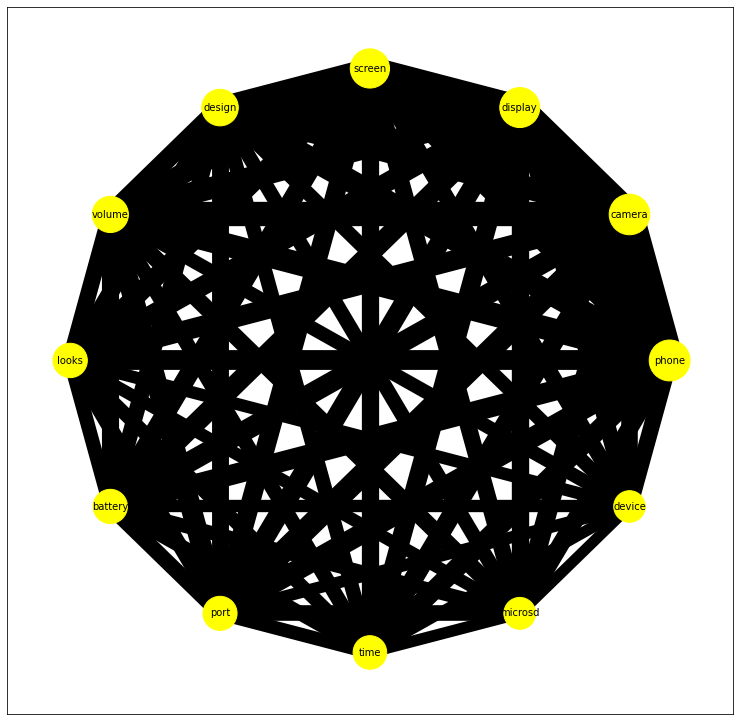

```python
plt.figure(figsize = (13, 13))
nx.draw_networkx(G, pos = nx.circular_layout(G),
                 nodelist = nodes, node_size = node_weights, edgelist = edges, width = edge_weights,
                 node_color = "yellow", with_labels = True, font_size = 10)
plt.draw()
```

#### Types of layout: Random

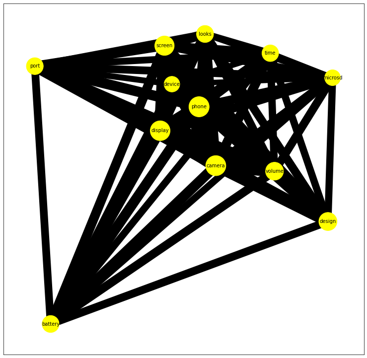

```python
plt.figure(figsize = (13, 13))
nx.draw_networkx(G, pos = nx.random_layout(G, seed = 0),
                 nodelist = nodes, node_size = node_weights, edgelist = edges, width = edge_weights,
                 node_color = "yellow", with_labels = True, font_size = 10)
plt.draw()
```

#### Types of layout: Spring

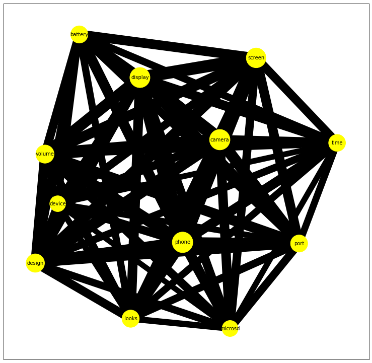

```python
plt.figure(figsize = (13, 13))
nx.draw_networkx(G, pos = nx.spring_layout(G),
                 nodelist = nodes, node_size = node_weights, edgelist = edges, width = edge_weights,
                 node_color = "yellow", with_labels = True, font_size = 10)
plt.draw()
```

### Focusing on a specific node of interest

```python
def plot_network(dataframe, target_word, num_nodes=30, node_multiplier=1, edge_divisor=1):
    target_word = target_word.lower()

    counter = Counter()
    co_counter = dict()

    #######################################################################
    # co_counter only has the co-occurrence information of the target word.
    #######################################################################
    co_counter[target_word] = dict()

    for l in dataframe.words:
        word_set = set()

        for item in l:
            word = item.lower()

            if word not in (global_stopwords + local_stopwords):
                word_set.add(word)

        #######################################################################
        # Exclude the current tweet if it does not have the target word.
        #######################################################################
        if target_word not in word_set:
            continue

        counter.update(word_set)

        words = list(word_set)

        for word in words:
            if word == target_word:
                continue

            if word not in co_counter[target_word]:
                co_counter[target_word][word] = 1
            else:
                co_counter[target_word][word] += 1

    G = nx.Graph()

    nodes = [item[0] for item in counter.most_common(num_nodes+1)]
    node_weights = [item[1] * node_multiplier for item in counter.most_common(num_nodes+1)]

    for word in nodes:
        G.add_node(word, weight=counter.get(word))

    for word in nodes:
        if (word != target_word) & (word2 in co_counter[target_word]):
            G.add_edge(target_word, word, weight=co_counter[target_word][word])

    edges = nx.get_edge_attributes(G, "weight").keys()

    edge_weights = nx.get_edge_attributes(G, "weight").values()

    edge_weights = [item / edge_divisor for item in edge_weights]

    plt.figure(figsize=(13, 13))
    nx.draw_networkx(G, pos=nx.spring_layout(G),
                     nodelist=nodes, node_size=node_weights, edgelist=edges, width=edge_weights,
                     node_color="yellow", with_labels=True, font_size=10)
    plt.draw()
```

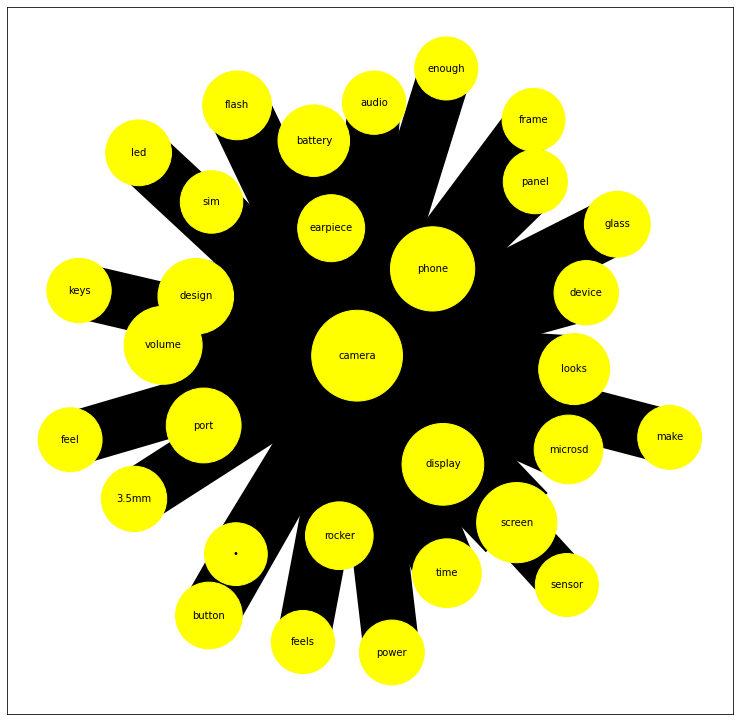

```python
plot_network(df, "camera", node_multiplier = 5, edge_divisor = 15)
```

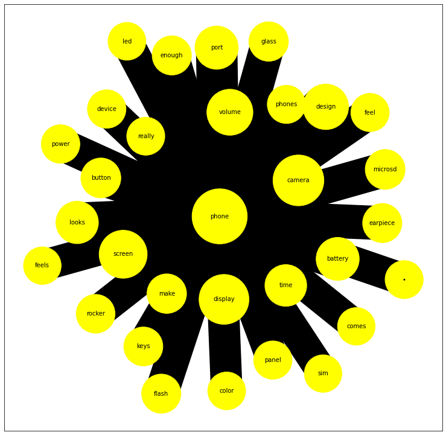

```python
plot_network(df, "phone", node_multiplier = 5, edge_divisor = 15)
```

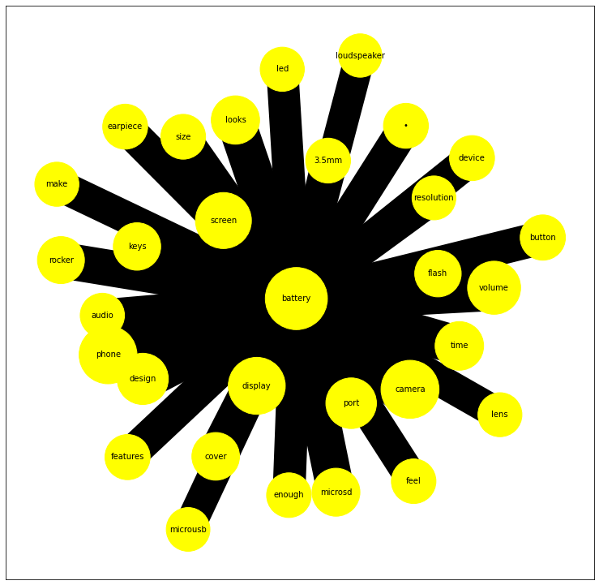

```python
plot_network(df, "battery", node_multiplier = 5, edge_divisor = 15)
```